# Pronósticos con regresión lineal

# 1 Introducción

El objetivo del análisis de regresión lineal es desarrollar o establecer un modelo lineal que explica el comportamiento de una variable (la cual llamaremos dependiente o explicada) a través de un grupo de una o más variables independientes (o explicativas), de esta manera la regresión lineal se refiere a una ecuación lineal que indica la relación que existe entre la variable dependiente con las independientes.

La regresión lineal se refiere a una función lineal con la siguiente forma:

$$y = \beta_0 + \beta_1 x_1+u \ \ \ \ \ (1)$$

$$y = \beta_0 + \beta_1 x_1+ \beta_2x_2+ u \ \ \ \ \ (2)$$

Ambas ecuaciones, son funciones lineales que describen el comportamiento o la relación que existe de $x_1$ sobre $y$ en la primera ecuación y la relación existente entre $x_1$ & $x_2$ sobre $y$ en la segunda ecuación. $y$ es la variable dependiente y $x_1$ y $x_2$ las variables independientes.

El problema consiste en tomar los datos observados: $y$, $x_1$ y $x_2$ para estimar la mejor función lineal que describa el comportamiento de la variable dependiente. Nota que ambas ecuaciones incluyen un término $u$, este es un error estócastico o aleatorio, el cual surge debido a que los modelos de regresión no son modelos deterministas, sino que más bien es probabilístico y es necesario establecer algunos supuestos sobre el comportamiento de este término de error.

En caso donde existe solo una variable independiente, se llama *regresión lineal simple*, y si tenemos más una variable independiente se le llama **regresión múltiple**, en todos los casos siempre tendremos **solo una variable independiente**. Si queremos analizar diferentes variables como función de otras, entonces debemos desarrollar una regresión lineal para cada una de las variables independientes.

Como parte de la notación o terminología que usaremos, cuando hablamos de regresión, ecuación de regresión, regresión lineal o modelo de regresión, nos referimos al mismo concepto, es decir, la ecuación que describe el comportamiento lineal de una variable dependiente como función de una o más variables independientes, como la ecuación 1 y 2.

Las variables observadas en una regresión linean son la variable dependiente y las independientes, mientras que **los parámetros** $\beta$ **así como el término de error no son observables**, el problema consiste en estimar estos coeficientes los cuales son los que determinan la relación que existe entre las variables.

Considera el siguiente ejemplo. Las ventas de una papelería en una colonia dependen de la población que vive en esa colonia, entre más personas vivan en esa zona mayor será la demanda de sus productos. La persona encargada de la tienda le interesa estimar el efecto promedio sobre sus ventas que tendría si aumenta (o disminuye) la población de la colonia, para ello propuso el siguiente modelo de regresión:

$$ventas=\beta_0+\beta_1población+u$$

Ventas, es una variable que se refiere al monto en pesos de las ventas realizadas y población es una variable que indica el número de personas que viven en la colonia, $\beta_0$ y $\beta_1$, son los coeficientes que deben ser estimados. Tomando datos de las ventas de su papelería y la población por año, al estimar la regresión obtuvo el siguiente resultado:

$$ventas=100+0.5población$$

Los resultados de esta regresión indican que $\beta_0=100$ y $\beta_1=0.5$. El signo de estos coeficientes determina la relación entre la población y las ventas; ya que estos resultados nos indican que sí la población en la colonia aumenta en una persona las ventas aumentan en 0.5 pesos, dado que $\beta_1$ es positivo, la relación entre la población y las ventas es positiva, si la población aumenta, también las ventas, si la población disminuye, las ventas disminuyen, ¿en cuánto? en 0.5 pesos por persona.

Nota que $\beta_0$ es también positivo e igual a 100, en una regresión este coeficiente representa una constante, ya que no depende de ninguna variable, en ese contexto indica que si no hay población en esta colonia, la papelería espera tener unas ventas mínimas de 100 pesos, ¿por qué? es muy probable que aunque las principales ventas sean por la población que viven en la misma colonia, una parte de las ventas se debe a compras que realizan personas que van de paso, de tal forma que la constante representa estas ventas. Dependiendo del problema que se esté analizando, el coeficiente que representa la constante en una regresión lineal puede o no tener un significado especifico.

El signo de los coeficientes asociados a un variable independiente determinan la relación entre las variables:

- Un coeficiente positivo indica una relación positiva o directa (sí $x$ aumenta $y$ también, si $x$ disminuye $y$ también)
- Un coeficiente negativo indica una relación negativa o inversa (si $x$ aumenta $y$ disminuye, si $x$ disminuye $y$ aumenta)
- La magnitud del impacto lo determina el valor del coeficiente, de hecho, nos interesa poder estimar un modelo *cuyos coeficientes sean estadísticamente significativos*, de lo contrario no serían útiles para explicar el comportamiento de la variable dependiente.

A manera de resumen, el análisis de regresión lo que nos indica es el efecto promedio esperado de una variable independiente sobre una variable dependiente, lo cual nos permite identificar la dependencia estadística que existe entre las variables, sin embargo, al ser un método estadístico, se necesitan cumplir ciertos supuestos sobre el comportamiento de las variables y los residuales para que los resultados sean válidos.

En estas notas resumiremos los conceptos y herramientas necesarias para realizar un análisis de regresión lineal básico y utilizarlo para realizar un pronóstico de nuestra variable de interés. Considera que detrás de muchas explicaciones se encuentran detalles técnicos, y algunos pueden llegar a ser complicados, por lo que no estaremos desarrollando detalladamente los aspectos matemáticos detrás del análisis de regresión, a favor de mostrar cómo realizar este análisis usando *R*, sin embargo, notarás cómo algunos conceptos como pruebas de hipótesis y distribuciones muestrales se vuelven relevantes para realizar este ejercicio.

# 2 Mínimos cuadrados ordinarios

La recta de regresión simple que se muestra a continuación:

$$y = \beta_0 + \beta_1 x_1+u$$

Es la recta de regresión poblacional, al igual que en los casos cuando se analiza la media o la proporción de una variable, en muchas ocasiones necesitamos tomar una muestra y utilizar la media muestra o la proporción muestral como un estimador puntual de los valores poblacionales, en el análisis de regresión sucede algo similar, dado que no conocemos los coeficientes de la población utilizamos los valores muestrales de la variable $y$ y $x$ para estimar una recta de regresión muestral, es decir, utilizamos los estadísticos $\hat{\beta_0}$ y $\hat{\beta_1}$ como estimadores de los coeficientes poblaciones $\beta_0$ y $\beta_1$, y con estos podemos construir la recta de regresión estimada:

$$\hat{y}=\hat{\beta_0}+\hat{\beta_1}x$$

Donde $x$ es la variable dependiente observada, pero ahora $\hat{y}$ es la variable dependiente estimada, el objetivo del análisis de regresión lineal es encontrar los mejores estadísticos $\hat{\beta_0}$ y $\hat{\beta_1}$ de tal manera que la diferencia entre la variable dependiente estimada y la observada sea la mínima posible, es decir, se busca minimizar la diferencia $y-\hat{y}$.

Esta diferencia es el residual:

$$\hat{u}=y-\hat{y}$$

$$\hat{u}=y-[\hat{\beta_0}+\hat{\beta_1}x]$$

Vale la pena añadir un subíndice $i$ a la expresión anterior, ya que esto indica que existe un residual para cada observación en mi tabla de datos, así como para cada observación corresponde un par $y$ y $x$. Donde $i=1,2,...,n$, y $n$ es el número de observaciones en nuestra muestra:

$$\hat{u_i}=y_i-(\hat{\beta_0}+\hat{\beta_1}x_i)$$

Sin embargo, necesitamos minimizar en conjunto **todos los residuales**, para ello simplemente tomamos la suma de los residuales y añadiendo un operador de suma a cada lado de la igualdad, obtenemos la siguiente expresión:

$$\sum\hat{u_i}=\sum (y_i-(\hat{\beta_0}+\hat{\beta_1}x_i))$$

Por último, necesitamos elevar al cuadrado ambos lados de la igualdad, ya que en general suma de los residuales es muy pequeña, un problema similar al que ocurren cuando se calcula la varianza de una variable, es necesario elevarla al cuadrado. Finalmente obtenemos la siguiente expresión y para poder minimizar la suma al cuadrado de esta diferencia, se utiliza el método de mínimos cuadrados ordinarios, de ahí el nombre del método.

$$\sum\hat{u}_i^2=\sum (y_i-(\hat{\beta_0}+\hat{\beta_1}x_i))^2$$

La expresión anterior indica que la suma de los residuales al cuadrado, son una función de los coeficientes estimados, es decir: $\sum\hat{u}_i^2=f(\hat{\beta_0},\hat{\beta_1})$, para minimizar esta expresión, basta con calcular las condiciones de primer orden, es decir las primeras derivadas parciales: $\frac{\delta\sum\hat{u}_i^2}{\delta\hat{\beta_0}}$ y $\frac{\delta\sum\hat{u}_i^2}{\delta\hat{\beta_1}}$, para resolver un sistema de dos ecuaciones con dos incognitas.

No entraremos en los detalles técnicos del método, ya que dependeremos de *R* para que realice todos los cálculos necesarios y nos concentraremos en las funciones del software para estimar modelos de regresión simple y múltiple así como poder determinar qué tan bueno o malo es el modelo estimado, interpretar los resultados y realizar un pronóstico.

## 2.1 Residuales

En un análisis de regresión se necesita verificar que se cumplen los siguientes supuestos antes de continuar con la interpretación de los resultados:

- Los residuales tienen media cero y son normales
- Los residuales son homocedásticos, es decir, la varianza de los residuales tiene una varianza constante para los diferentes valores de $x$ (cuando se rompe este supuesto se dice que los errores son heterocedásticos)
  - La existencia de valores atípicos generalmente es una causa de heterocedasticidad
- No hay autocorrelación en los errores

Es muy común que para verificar estos supuestos se utilicen métodos gráficos, sin embargo, aunque son muy didácticos cuando los datos exhiben un patrón muy obvio que se aleja de los supuestos, existen pruebas de hipótesis para verificar la validez de estos supuestos.

# 3 Regresión lineal simple

A continuación estimaremos un modelo de regresión simple, utilizando los datos simulados que se encuentran en el archivo de excel “datos_simple.xlsx”, este archivo contiene solo dos variables una dependiente ($y$) y una independiente ($x$). Puedes descargar estos datos [AQUÍ](https://github.com/analitycsmiike/forecasting/raw/main/datos_simple.xlsx). Con estos datos podemos estimar la siguiente ecuación:

$$y=\beta_0+\beta_1x+u$$

Comenzamos cargando los datos de manera habitual, recuerda establecer tu directorio y poner tus datos en esta misma carpeta. En esta practica será necesario descargar varias librerías. A continuación mostraremos las funciones para realizar un análisis de regresión lineal simple, describiendo los resultados obtenidos y su interpretación, así como las funciones para realizar el análisis de residuales. Posteriormente se mostrará el mismo procedimiento para una regresión lineal múltiple, donde las funciones son las mismas y solo cambia la cantidad de variables del modelo.

Establece el directorio de trabajo, recuerda que debe ser la dirección de la carpeta donde están tus bases de datos, por ejemplo, reemplaza la palabra “dirección” por la ruta de la carpeta:

```r
setwd(dirname(direccion))
```

Cargamos las librerías necesarias y los datos. Tras cargar los datos podemos observar que solo contiene dos variables con nombres genéricos:

```r
library(readxl)
library(tidyverse)
library(lubridate)
library(modelr)
library(sandwich)
library(tseries)
library(lmtest)
library(forecast)


base1 <- read_excel("datos_simple.xlsx")

str(base1)
```

```
## tibble [500 x 2] (S3: tbl_df/tbl/data.frame)
##  $ y: num [1:500] 68.2 53.9 76.7 67.2 59.3 ...
##  $ x: num [1:500] 4.65 3.11 5.63 4.51 4.1 ...
```

Para estimar el modelo de regresión debemos utilizar la función *lm* la cual permite estimar modelos lineales, la sintaxis es la siguiente, debemos guardar este modelo en un objeto, ya que genera información que necesitaremos más adelante. La sintaxis de la función *lm* requiere indicar primero la ecuación que se desea estimar, indicando primero la variable dependiente y después del signo *~* las variables independientes, en este caso al ser una regresión simple, solo se indica una variable, finalmente se debe indicar en la opción *data* el nombre del objeto donde tomará los datos en este caso el objeto que llamamos *base1*:

```r
modelo <- lm(y ~ x, data=base1)
```

Para ver los resultados solo indicamos indicados el nombre del objeto, el cual nos muestra la fórmula utilizada y los coeficientes, el intercepto se refiere a la constante & $x$ al coeficiente asociado la variable independiente:

```r
modelo
```

```
##
## Call:
## lm(formula = y ~ x, data = base1)
##
## Coefficients:
## (Intercept)            x
##       20.79        10.07
```

Con estos datos, podemos decir que la ecuación de regresión estimada es:

$$y=20.79+10.07x$$
Otra forma de ver los resultados de manera completa es pedir un *summary* al objeto de la regresión, de esta forma nos reporta mucha más información para ver el ajuste del modelo:

```r
summary(modelo)
```

```
##
## Call:
## lm(formula = y ~ x, data = base1)
##
## Residuals:
##     Min      1Q  Median      3Q     Max
## -2.7267 -0.7023  0.0306  0.7625  3.4174
##
## Coefficients:
##             Estimate Std. Error t value Pr(>|t|)
## (Intercept)  20.7859     0.2410   86.26   <2e-16 ***
## x            10.0708     0.0471  213.81   <2e-16 ***
## ---
## Signif. codes:  0 '***' 0.001 '**' 0.01 '*' 0.05 '.' 0.1 ' ' 1
##
## Residual standard error: 1.044 on 498 degrees of freedom
## Multiple R-squared:  0.9892, Adjusted R-squared:  0.9892
## F-statistic: 4.572e+04 on 1 and 498 DF,  p-value: < 2.2e-16
```

En la parte superior muestra la regresión estimada. Debajo de esto los residuales, indicando algunas medidas de dispersión. Seguido una tabla de coeficientes donde nos muestra la estimación puntual, el error estándar, el estadístico t y su valor-p. En la parte inferior nos muestra el erro estándar de los residuales, una medida de ajuste que se llama $r^2$ y $r^2$ ajustado, y un estadístico F con sus grados de libertad y su valor-p. Esta información es necesaria para validar el ajuste del modelo, es decir, tener una medida de que tan bueno es la regresión estimada. Recuerda que el error estándar de los residuales es el error estándar de la regresión.

La primera parte de los resultados muestra algunas medias de dispersión de los residuales, recuerda que se busca que sean normales con media cero.

Los coeficientes estimados al ser estadísticos tienen por lo tanto una distribución muestral, siguiendo una distribución t, y podemos realizar pruebas de hipótesis e intervalos de confianza sobre los valores de estos coeficientes, para ello la función reporta no solo la estimación del coeficiente sino también su error estándar. De hecho, la prueba de hipótesis “predeterminada” que realiza la función es para probar la hipótesis nula de que el coeficiente es igual a cero.
$$H_0: \beta_1=0$$
$$H_a: \beta_1\neq0$$

Si no podemos rechazar esta hipótesis nula, indica que el efecto que tiene la variable independiente sobre $y$ es estadísticamente igual a cero, por lo tanto, no es una variable que explique comportamiento de la dependiente. El estadístico t y el valor-p que se reporta en la función de regresión están asociados a esta prueba de hipótesis, los cuales se pueden verificar con algunos cálculos.

Una variable independiente será:

- significativa **SÍ SE** rechaza la hipótesis nula de que su coeficiente estimado es igual a cero
- no significativa **SÍ NO** se rechaza la hipótesis nula de que su coeficiente estimado es igual a cero, es decir, resulta estadísticamente igual a cero

La $r^2$ es el coeficiente de determinación y es una medida de bondad de ajuste del modelo, lo que indica es el porcentaje de la variación en $y$ que es explicada por la regresión o por las variables independientes. La varianza de la variable dependiente $y$ puede seperarse en dos partes, una parte explicada por el modelo y una parte no explicada, la variación no explicada se refiere a los residuales.

$$Variación \ de \ y= Variación \ Explicada + Variación \ no \ explicada$$
Entonces

$$r^2=\frac{Variación \ Explicada}{Variación \ de \ y}$$
O también

$$r^2=1-\frac{Variación \ no \ explicada}{Variación \ de \ y}$$

En general, entre mayor sea la $r^2$ mayor poder explicativo tiene el modelo sobre la variable dependiente, añadir más variables al modelo aumenta este coeficiente, independientemente si las variables resultan significativas o no. Es por ello que también se presenta el $r^2$ ajustado, este es el coeficiente de determinación que se ajusta penalizando el número de variables independientes que se introducen al modelo.

Finalmente, la última parte de la regresión muestra un estadístico F, este estadístico es el resultado de una prueba de hipótesis sobre la significancia total de las variables, y es una prueba complementaria sobre todo cuando se realiza un análisis de regresión lineal múltiple. Este estadístico analiza la siguiente prueba de hipótesis:

$$H_0: \beta_1=\beta_2=...=\beta_k=0$$

$$H_a: al \ menos \ un \ coeficiente \ es \ diferente \ de \ cero$$

A diferencia de las pruebas t individuales, la idea detrás de esta prueba F, es un análisis de dos varianzas, sí todos los coeficientes son iguales cero (o estadísticamente iguales a cero) la variación explicada será igual a la varianza de los residuales, y por lo tanto el estadístico F será igual uno, si son diferentes, el estadístico F será diferente de uno.

## 3.1 Residuales

Antes de continuar con la interpretación de los coeficientes, es necesario verificar que se cumplan los supuestos de los residuales.

Para realizar pruebas formales necesitamos estimar los residuales de la regresión y añadirlo a nuestra tabla de datos inicial, para estimar o predecir los valores residuales solo debemos utilizar la función *add_residuals()* la cual forma parte de la librería *modelr*, con la siguiente instrucción estamos añadiendo a nuestra tabla de datos una variable que se llama *resid*, la cual contiene los residuales estimados de la regresión:

```r
base1<- base1 %>%
  add_residuals(modelo)
```

Para determinar si son media cero y se distribuyen normalmente, basta con pedir la media de la variable, o hacer un histograma, como se muestra a continuación:

```r
summary(base1$resid)
```

```
##     Min.  1st Qu.   Median     Mean  3rd Qu.     Max.
## -2.72665 -0.70230  0.03062  0.00000  0.76254  3.41737
```

Sin embargo, una prueba formal para validar si los residuales de una regresión son normales o no sería realizar la prueba de normalidad de Jarque-Bera, la cual prueba la hipótesis nula de que la variable se distribuye normalmente, contra la alternativa de que la variable no es normal, para utilizar esta prueba es necesario llamar a la librería *tseries*, y utilizar la función *jarque.bera.test()*, simplemente debemos indicar la variable a la cual realiza la prueba:

```r
jarque.bera.test(base1$resid)
```

```
##
##  Jarque Bera Test
##
## data:  base1$resid
## X-squared = 0.44563, df = 2, p-value = 0.8003
```

La prueba de Jarque-Bera utiliza un estadístico $\chi^2$, el cual muestra un valor pequeño y por lo tanto un valor-p grande, de 0.8003, lo cual no permite rechazar la hipótesis nula de que los residuales son normales. Aunque existen diferentes pruebas de normalidad, la de Jarque-Bera es bastante utilizada.

Aunque los residuales son normales, debemos verificar que sean homocedásticos, para determinar esto es necesario realizar una prueba de heterocedasticidad, entre las diversas pruebas que existen, la de Breuch-Pagan es una de más comunes, para realizar esta prueba es necesario cargar la librería *lmtest* y utilizar la función *bptest()* simplemente indicando el objeto que contiene la estimación realizada:

```r
bptest(modelo)
```

```
##
##  studentized Breusch-Pagan test
##
## data:  modelo
## BP = 1.2066, df = 1, p-value = 0.272
```

La hipótesis nula de la prueba es que los errores son homocedásticos, contra la hipótesis alternativa de que los errores son heterocedásticos. El estadístico de prueba es un estadístico $\chi^2$, al ser pequeño su valor-p es alto y por lo tanto no es posible rechazar la hipótesis nula, lo cual es deseable.

Una forma sencilla para probar si existe autocorrelación de primer grado, es analizar estadístico Durbin - Watson, este se calcula utilizando los residuales, bajo el supuesto de que no existe autocorrelación entonces su valor debe ser igual 2, de lo contrario se dice que existe autocorrelación de primer grado.

Utilizando la función *dwtest* podemos fácilmente calcular este estadístico y nuestro caso es prácticamente igual 2, por lo tanto, no tenemos un problema de autocorrelación.

```r
dwtest(modelo)
```

```
##
##  Durbin-Watson test
##
## data:  modelo
## DW = 2.0638, p-value = 0.7621
## alternative hypothesis: true autocorrelation is greater than 0
```

## 3.2 Interpretación

Con todos estos elementos podemos revisar los resultados de la regresión, ya que no hay ningún problema con los residuales de la regresión pues: son normales, con media cero , homocedásticos y no existe autocorrelación de primer grado.

```r
summary(modelo)
```

```
##
## Call:
## lm(formula = y ~ x, data = base1)
##
## Residuals:
##     Min      1Q  Median      3Q     Max
## -2.7267 -0.7023  0.0306  0.7625  3.4174
##
## Coefficients:
##             Estimate Std. Error t value Pr(>|t|)
## (Intercept)  20.7859     0.2410   86.26   <2e-16 ***
## x            10.0708     0.0471  213.81   <2e-16 ***
## ---
## Signif. codes:  0 '***' 0.001 '**' 0.01 '*' 0.05 '.' 0.1 ' ' 1
##
## Residual standard error: 1.044 on 498 degrees of freedom
## Multiple R-squared:  0.9892, Adjusted R-squared:  0.9892
## F-statistic: 4.572e+04 on 1 and 498 DF,  p-value: < 2.2e-16
```

Los coeficientes son positivos y significativos, esto debido a que podemos rechazar la prueba de hipótesis de que ambos coeficientes son iguales a cero (nota que el estadístico t de ambos coeficientes es muy grande y por lo tanto su valor-p es prácticamente cero, mostrando evidencia en contra de la hipótesis nula). La $r^2$ es de 0.9892 o 98.92%, lo que indica que el modelo de regresión explica el 99% de la variación de $y$, al ser un modelo de regresión simple, la $r^2$ ajustada es igual.

La regresión muestra que existe una relación positiva y significativa al 1% entre $x$ y $y$, de tal manera que si $x$ aumenta en una unidad, $y$ aumenta en promedio 10 unidades. Cuando $x$ es igual cero, el valor esperado de $y$ es de 20.78, esto debido al valor de la constante.

Nota que los coeficientes asociados a la variable independiente nos indican el cambio esperado en $y$ por un cambio en $x$; es decir, supongamos que $x$ pasa de $x_1$ a $x_2$, donde $x_1=0$ a $x_2=1$, según la ecuación de regresión:

$$Sí \ x=0 : y_1=20.79+10.07(0)=20.79$$
$$Ahora \ x=1: y_2=20.79+10.07(1)=30.86$$
El cambio en $\Delta y$, es la diferencia: $y_2 - y_1=10.07$, la cual podemos simplificar: $y_2=\beta_0+\beta_1 x_2$ y $y_1=\beta_0+\beta_1 x_1$, entonces $\Delta y=\beta_0+\beta_1x_2-\beta_0-\beta_1x_1$, por lo tanto $\Delta y=\beta_1(x_2-x_1)$, lo cual podemos resumir en la siguiente expresión:

$$\Delta y=\beta_1 \Delta x$$

Por simplicidad, podemos asumir que $\Delta x=1$, y el coeficiente representaría el efecto de una unidad de $x$ sobre $y$, sin embargo, también puede usarse la expresión anterior para analizar impactos de magnitud diferente, por ejemplo, que pasa si repentinamente $x$ aumenta en 30 unidades, ¿cuál es el efecto esperado sobre $y$?

Nota que, estamos considerando el *efecto* o *cambio esperado* sobre $y$, no el valor final de $y$, para predecir el valor final de $y$ tendríamos que utilizar la ecuación completa considerando el valor de la constante.

## 3.3 Transformación de variables

Es común en muchos análisis de regresión lineal encontrar que se realizan transformaciones a las variables, una de las formas más comunes es utilizar las variables en logaritmos naturales, esto genera que la forma funcional sea diferente y por lo tanto la interpretación de los coeficientes cambia, considera los siguientes ejemplos comunes. Sea $y$ una variable dependiente y $x$ una variable independiente.

Si se estima la ecuación: $y=\beta_0+\beta_1x+u$:

- por un aumento en una unidad de $x$, $y$ aumenta $\beta_1$ unidades

Si se estima la ecuación: $ln(y)=\beta_0+\beta_1x+u$:

- por un aumento en una unidad de $x$, $y$ aumenta ($\beta_1*100$)%

Si se estima la ecuación: $y=\beta_0+\beta_1ln(x)+u$

- por un aumento en 1% de $x$, $y$ aumenta $\frac{\beta_1}{100}$ unidades

Si se estima la ecuación: $ln(y)=\beta_0+\beta_1ln(x)+u$

- por un aumento en 1% de $x$, $y$ aumenta $\beta_1$%

## 3.4 Variables categóricas

Dentro del análisis de regresión, es posible añadir variables categóricas como variables independientes. Una variable categórica es aquella que describe algunas características de los individuos (o unidades) que se están analizando, por ejemplo, si hablamos de personas, podemos tener una variable categórica que indique el sexo, la religión, la preferencia sexual, la entidad de residencia, etc. Si hablamos de series de tiempo, podemos agregar variables categoricas para el mes de referencia, la estación del año, o una fecha en especifico.

Para añadir este tipo de variables al análisis se debe hacer en forma de variables binarias (es decir, aquellas que solo toman el valor de cero y uno) y son de manera comparativa. Una variable categórica que tiene $m$ categorías, y la cual deseamos introducir en el análisis de regresión, debemos generar $m-1$ variables binarias, la categoría que sea omitida es la base con la cual se comparan las demás variables.

Afortunadamente el software nos ayudará a generar estas variables binarias, solo debemos asegurarnos de que nuestra variable categórica esta de tipo factor.

# 4 Regresión lineal múltiple

Ahora consideremos el caso de una regresión lineal múltiple, caso en el cual tenemos más de dos variables independientes:

$$y=\beta_0+\beta_1x_1+...+\beta_kx_k+u$$

A continuación estimaremos un modelo de regresión múltiple, utilizando los datos simulados que se encuentran en el archivo de excel “datos_múltiple.xlsx”, este archivo contiene cuatro variables una dependiente ($y$) y tres variables independientes ($x_1, x_2,x_3$). Puedes descargar estos datos [AQUÍ](https://github.com/analitycsmiike/forecasting/raw/main/datos_multiple.xlsx). Con estos datos podemos estimar la siguiente ecuación:

$$y=\beta_0+\beta_1x_1+\beta_2x_2+\beta_3x_3+u$$

Cargamos los datos en un objeto llamado base2:

```r
base2 <- read_excel("datos_multiple.xlsx")

str(base2)
```

```
## tibble [120 x 4] (S3: tbl_df/tbl/data.frame)
##  $ y : num [1:120] 165.2 63.9 114.6 151.5 174.8 ...
##  $ x1: num [1:120] 9.31 6.21 11.27 9.01 8.19 ...
##  $ x2: num [1:120] 0.14641 1.92763 0.00648 2.0569 4.48619 ...
##  $ x3: num [1:120] 3.4417 -0.4454 -0.0658 0.3598 5.7224 ...
```

Las funciones y librerías son las mismas que en el caso de una regresión simple, solo cambia un poco la sintaxis al momento de estimar la regresión, debemos añadir las variables independientes añadiendo el signo de **+**,

```r
modelo_multiple <- lm(y ~ x1 + x2 + x3, data=base2)

modelo_multiple
```

```
##
## Call:
## lm(formula = y ~ x1 + x2 + x3, data = base2)
##
## Coefficients:
## (Intercept)           x1           x2           x3
##      36.302        9.596        8.783        6.027
```

```r
summary(modelo_multiple)
```

```
##
## Call:
## lm(formula = y ~ x1 + x2 + x3, data = base2)
##
## Residuals:
##     Min      1Q  Median      3Q     Max
## -70.098 -12.628  -3.554  16.089  75.800
##
## Coefficients:
##             Estimate Std. Error t value Pr(>|t|)
## (Intercept)  36.3019    11.6999   3.103  0.00241 **
## x1            9.5959     1.1237   8.540 6.08e-14 ***
## x2            8.7831     1.0896   8.061 7.60e-13 ***
## x3            6.0269     0.5651  10.666  < 2e-16 ***
## ---
## Signif. codes:  0 '***' 0.001 '**' 0.01 '*' 0.05 '.' 0.1 ' ' 1
##
## Residual standard error: 23.93 on 116 degrees of freedom
## Multiple R-squared:  0.6794, Adjusted R-squared:  0.6711
## F-statistic: 81.95 on 3 and 116 DF,  p-value: < 2.2e-16
```

Le ecuación de regresión estimada seria entonces:
$$y=36.30+9.59x_1+8.78x_2+6.02x_3$$

## 4.1 Residuales

Recuerda que antes de interpretar los resultados necesitamos verificar si se cumplen los supuestos de los residuales o no.

```r
base2<- base2 %>%
  add_residuals(modelo_multiple)

summary(base2$resid)
```

```
##    Min. 1st Qu.  Median    Mean 3rd Qu.    Max.
## -70.098 -12.628  -3.554   0.000  16.089  75.800
```

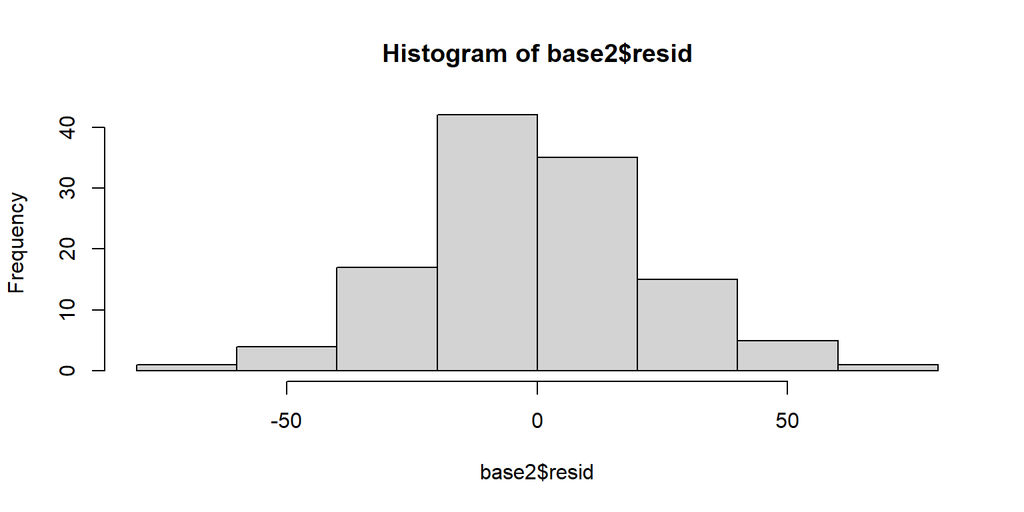

```r
hist(base2$resid)
```

```r
jarque.bera.test(base2$resid)
```

```
##
##  Jarque Bera Test
##
## data:  base2$resid
## X-squared = 2.7957, df = 2, p-value = 0.2471
```

```r
bptest(modelo_multiple)
```

```
##
##  studentized Breusch-Pagan test
##
## data:  modelo_multiple
## BP = 2.413, df = 3, p-value = 0.4912
```

```r
dwtest(modelo)
```

```
##
##  Durbin-Watson test
##
## data:  modelo
## DW = 2.0638, p-value = 0.7621
## alternative hypothesis: true autocorrelation is greater than 0
```

Además, cuando se realiza un análisis de regresión múltiple, se debe verificar que las variables independientes no están fuertemente correlacionadas entre sí, de lo contrario, tendremos un problema de multicolinelidad, es de decir, que la relación lineal entre las variables independientes es muy alta y esto genera problemas en la estimación de la regresión. Una forma sencilla de verificar que existe multicolinealidad es verificar la correlación entre las variables independientes, si existe una alta correlación entre ellas, y además el modelo de regresión presenta un alto coeficiente de determinación y pocas variables significativas, son un indicio de multicolinealidad. Se puede optar por eliminar una de las variables que estén fuertemente correlacionadas.

En nuestro ejemplo, al realizar un análisis de correlación observamos que la correlación entre las variables independientes es baja:

```r
base2 %>%
  select(x1,x2,x3) %>%
  cor()
```

```
##             x1          x2          x3
## x1  1.00000000 -0.05872322  0.08086442
## x2 -0.05872322  1.00000000 -0.08905364
## x3  0.08086442 -0.08905364  1.00000000
```

## 4.2 Interpretación

Ahora que verificamos que el modelo de regresión múltiple estimado cumple con los supuestos, podemos interpretar los resultados:

```r
summary(modelo_multiple)
```

```
##
## Call:
## lm(formula = y ~ x1 + x2 + x3, data = base2)
##
## Residuals:
##     Min      1Q  Median      3Q     Max
## -70.098 -12.628  -3.554  16.089  75.800
##
## Coefficients:
##             Estimate Std. Error t value Pr(>|t|)
## (Intercept)  36.3019    11.6999   3.103  0.00241 **
## x1            9.5959     1.1237   8.540 6.08e-14 ***
## x2            8.7831     1.0896   8.061 7.60e-13 ***
## x3            6.0269     0.5651  10.666  < 2e-16 ***
## ---
## Signif. codes:  0 '***' 0.001 '**' 0.01 '*' 0.05 '.' 0.1 ' ' 1
##
## Residual standard error: 23.93 on 116 degrees of freedom
## Multiple R-squared:  0.6794, Adjusted R-squared:  0.6711
## F-statistic: 81.95 on 3 and 116 DF,  p-value: < 2.2e-16
```

Todas las variables tienen coeficientes positivos, y todos resultaron ser estadísticamente significativos, es decir, en todos los casos se puede rechazar la hipótesis nula de que coeficiente estimado es igual a cero.

La $r^2$ es de 67.94%, mientras que la $r^2$ ajustada es de 67.11%, recuerda que este último penaliza la cantidad de variables que se introducen al modelo.

El estadístico F es de 81.95 y su valor-p es prácticamente cero, por lo tanto podemos rechazar la hipótesis nula de que los coeficientes ($\beta_1, \beta_2 \ y \beta_3$) son iguales cero, concluyendo que el modelo en general es significativo.

## 4.3 Intervalos de confianza y errores robustos

Como mencionamos en la introducción de este capítulo, los coeficientes estimados de una regresión son estadísticos y siguen una distribución t, por ello podemos calcular intervalos de confianza, los cuales pueden complementar el análisis en vez de solo utilizar las estimaciones puntuales. La forma de calcular un intervalo de confianza es similar al de una media, tomamos un estimador puntual más menos un margen de error.

Una forma sencilla de calcular los intervalos de confianza para los coeficientes es utilizar la función *coefci()*, de la paquetería *lmtest*, solo debemos indicar el objeto donde se encuentra la regresión y el nivel de confianza que sea desea:

```r
coefci(modelo_multiple, level=.95)
```

```
##                 2.5 %    97.5 %
## (Intercept) 13.128726 59.475158
## x1           7.370299 11.821541
## x2           6.625072 10.941202
## x3           4.907739  7.146062
```

El uso de los intervalos de confianza para analizar los coeficientes de regresión es útil, pues nos da una idea de los valores que puede tener el coeficiente de la variable, entre mayor sea el error estándar del coeficiente estimado más amplio será el intervalo.

Para calcular los errores estándar robustos es necesario instalar la paquetería *sandwich* para utilizar la función *vcovHC* y junto con la función *coeftest* de la librería *lmtest*, poder estimar errores estándar robustos con heterocedasticidad. Esto es útil cuando nuestro modelo presenta heterocedasticidad.

```r
coeftest(modelo_multiple, vcov = vcovHC(modelo_multiple, type="HC1"))
```

```
##
## t test of coefficients:
##
##             Estimate Std. Error t value  Pr(>|t|)
## (Intercept) 36.30194   13.51581  2.6859  0.008295 **
## x1           9.59592    1.29308  7.4210 2.098e-11 ***
## x2           8.78314    1.20992  7.2593 4.787e-11 ***
## x3           6.02690    0.51984 11.5938 < 2.2e-16 ***
## ---
## Signif. codes:  0 '***' 0.001 '**' 0.01 '*' 0.05 '.' 0.1 ' ' 1
```

Además, podemos también calcular los intervalos de confianza, utilizando los errores estándar robustos:

```r
coefci(modelo_multiple ,vcov = vcovHC(modelo_multiple, type="HC1"))
```

```
##                2.5 %    97.5 %
## (Intercept) 9.532169 63.071715
## x1          7.034812 12.157028
## x2          6.386733 11.179541
## x3          4.997296  7.056505
```

# 5 Pronósticos usando regresión lineal

Hasta ahora hemos mostrado como estimar una regresión para identificar la relación existente entre las variables independientes y la variable dependiente, de esta manera con los coeficientes estimados podemos analizar el efecto esperado que tiene una variación de las variables independientes sobre la dependiente.

Podemos realizar un análisis de regresión para generar pronósticos, la idea es modelar la variable dependiente (nuestra serie de tiempo de interés) como una función de los componentes de una serie de tiempo; su tendencia y estacionalidad (si existe), con ello obtendremos los coeficientes asociados a estos componentes y ver el cambio esperado en la variable cuando el tiempo aumente en un periodo.

Analizaremos las formas de analizar una regresión de series de tiempo y posteriormente mostraremos un ejemplo de pronóstico de series con diferentes frecuencias de tiempo.

En estos ejemplos utilizaremos la base de datos “BD_INDICADORES_MACROECONOMICOS.xlsx”, que publica el IIEG, puedes descarga la base de datos [AQUI](https://github.com/analitycsmiike/forecasting/raw/main/BD_INDICADORES_MACROECONOMICOS.xlsx).

## 5.1 Modelado de la tendencia

Es común que las series de tiempo tengan tendencia, podemos modelar una tendencia lineal como regresión de la siguiente forma:

$$y_t=\beta_0+\beta_1t+u_t$$

Donde $t=1,2,...T$ es la periodo de tiempo, $y_t$ es nuestra serie de tiempo que deseamos pronosticar, $\beta_0$ la constante y $\beta_1$ el coeficiente asociado a la tendencia lineal.

De esta manera, solo necesitamos estimar una regresión simple donde la única la variable independiente es la variable de tiempo, o una variable consecutiva que indique la sucesión de las variables para diferentes periodos, considera el siguiente ejemplo.

El PIB de México se presenta en la siguiente tabla para el periodo 2003-2020.

| Año | PIB |
| --- | --- |
| 2003 | 12,559,105 |
| 2004 | 13,050,687 |
| 2005 | 13,347,722 |
| 2006 | 13,931,384 |
| 2007 | 14,254,464 |
| 2008 | 14,402,757 |
| 2009 | 13,648,547 |
| 2010 | 14,352,401 |
| 2011 | 14,875,797 |
| 2012 | 15,430,993 |
| 2013 | 15,642,620 |
| 2014 | 16,067,158 |
| 2015 | 16,579,414 |
| 2016 | 16,982,550 |
| 2017 | 17,329,809 |
| 2018 | 17,701,265 |
| 2019 | 17,668,442 |
| 2020 | 16,266,511 |

Para modelar una regresión lineal con la tendencia necesito estimar la siguiente regresión lineal:

$$PIB_t=\beta_0+\beta_1t+u$$

Donde $PIB_t$ es el PIB de México para el año $t$, $t=2003,2004,...,2020$, por lo tanto la variable independiente es el Año:

$$PIB_t=\beta_0+\beta_1Año+u$$

Por lo tanto al estimar la ecuación tendría el siguiente resultado:

$$PIB=-571365216+291620Año$$

Nota como por efecto de medir el tiempo con los años, la constante termina siendo negativa, para ajustar nuestra serie basta con cambiar la variable de tiempo a una variable discreta que indique el número de años, es decir:

| Año | PIB | t |
| --- | --- | --- |
| 2003 | 12,559,105 | 1 |
| 2004 | 13,050,687 | 2 |
| 2005 | 13,347,722 | 3 |
| 2006 | 13,931,384 | 4 |
| 2007 | 14,254,464 | 5 |
| 2008 | 14,402,757 | 6 |
| 2009 | 13,648,547 | 7 |
| 2010 | 14,352,401 | 8 |
| 2011 | 14,875,797 | 9 |
| 2012 | 15,430,993 | 10 |
| 2013 | 15,642,620 | 11 |
| 2014 | 16,067,158 | 12 |
| 2015 | 16,579,414 | 13 |
| 2016 | 16,982,550 | 14 |
| 2017 | 17,329,809 | 15 |
| 2018 | 17,701,265 | 16 |
| 2019 | 17,668,442 | 17 |
| 2020 | 16,266,511 | 18 |

En lugar de usar $Año$ como variable dependiente usamos la variable $t$, obtenemos los siguientes resultados:

$$PIB=12456928+291620t$$

Nota como los coeficientes son asociados al tiempo (tendencia) son iguales, por lo tanto el aumento de un año tendría un efecto sobre el PIB en 291,620 millones de pesos.

Pero este no es un pronóstico, para realizar el pronóstico para el año $T+1$, es decir, para el año 2021, necesito evaluar la ecuación completa utilizando la ecuación de regresión estimada, es decir, tomando en cuenta la constante, entonces el pronóstico para los siguientes tres años seria:

$$PIB_{2021}=12456928+291620(19)=17997708$$

$$PIB_{2022}=12456928+291620(20)=18289328$$

$$PIB_{2023}=12456928+291620(21)=18580948$$

Estos son pronósticos puntuales, por lo tanto podemos calcular también intervalos de predicción, para una regresión simple de la siguiente forma:

$$\hat{y}_t=\hat{\beta_0}+\hat{\beta_1}x$$

Un intervalo de predicción al 95% para cada punto se calcula utilizando la siguiente formula:

$$\hat{y}_t \pm 1.96\hat{\sigma}_u\sqrt{1+\frac{1}{T}+\frac{x-\overline{x}}{T-1}s^2_x}$$

Donde $T$ es el número total de observaciones, $\overline{x}$ es la media de los variable independiente, $s^2_x$ es la desviación estándar de la variable independiente y $\hat{\sigma}_u$ es el error estándar de la regresión. Si se desea un intervalo de predicción al 90% se sustituye 1.96 por 1.64 y para un intervalo al 99% por 2.58. Afortunadamente **R** nos ayudará a realizar los cálculos por nosotros, así como la conversión de una variable de tiempo a una variable discreta que indique el número de periodos.

## 5.2 Modelando la estacionalidad

Muchas series económicas y financieras presentan estacionalidad, sobre todo cuando trabajamos con series de mayor frecuencia, como trimestrales o mensuales. Por ejemplo, el consumo de gas suele aumentar durante los meses de invierno, las ventas sueles aumentar durante la navidad, durante enero el gasto de los hogares suele disminuir.

Podemos utilizar el modelo de regresión lineal para capturar estos efectos y cuantificarlos, esto lo hacemos a través de variables dicótomicas (o variables dummy o binarias como también se les conoce). Las variables dummy son aquellas que reportan con 0 cuando no se cumple alguna condición o característica y con uno 1 cuando sí se cumple.

Para tomar en cuenta la estacionalidad tenemos que generar variables dummy estacionales, según el tipo de frencuencia es el cantidad de variables a generar, por ejemplo, si tenemos una serie con periodicidad mensual, hay 12 categorías, es decir, 12 meses en el año. Si tenemos una serie con periodicidad trimestral, hay 4 categorías, es decir, 4 trimestres en el año. Cuando deseamos introducir las $m$ categorías que tenga una variable al modelo de regresión se necesitan generar $m-1$ variables dummy, esto para no caer en un error de multicolinealidad perfecta.

En resumen, si tenemos una serie mensual, se necesitan 11 variables dummy, si es una serie trimestral son necesarias 3 variables dummy y así para cualquier periodicidad.

Considera el siguiente ejemplo, los visitantes extranjeros que llegan a México se muestran en la siguiente gráfica para el periodo de enero 2012 a diciembre de 2019. Muestran un claro patrón estacional.

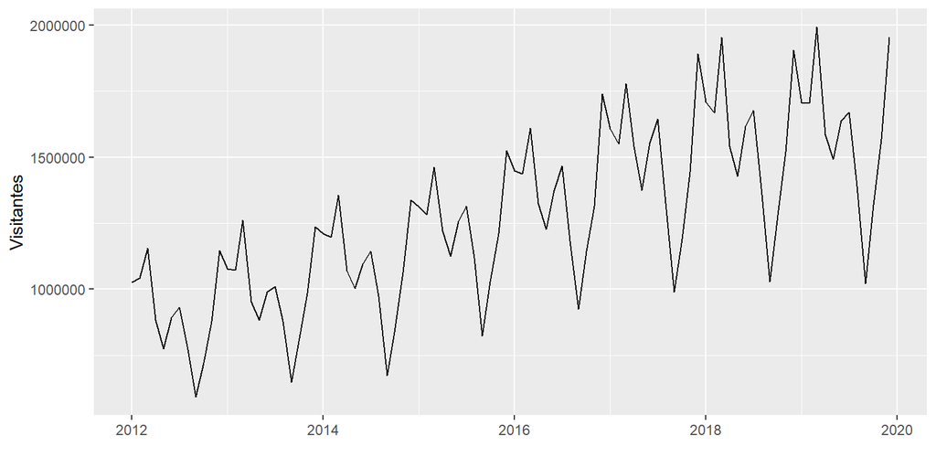

Si proponemos una regresión lineal utilizando solo la tendencia, igual que el ejemplo anterior, estaríamos dejando de considerar los patrones estacionales que tiene el turismo, sobre todo los periodos vacaciones cuando el flujo de visitantes se incrementa considerablemente, y podríamos tener pronósticos fuera de lo esperado:

| year | mes | Visitantes | t |
| --- | --- | --- | --- |
| 2012 | enero | 1,026,996 | 1 |
| 2012 | febrero | 1,042,311 | 2 |
| 2012 | marzo | 1,155,655 | 3 |
| 2012 | abril | 884,032 | 4 |
| 2012 | mayo | 773,678 | 5 |
| 2012 | junio | 891,388 | 6 |
| 2012 | julio | 932,461 | 7 |
| 2012 | agosto | 782,781 | 8 |
| 2012 | septiembre | 591,795 | 9 |
| 2012 | octubre | 720,182 | 10 |
| 2012 | noviembre | 878,891 | 11 |
| 2012 | diciembre | 1,146,156 | 12 |
| 2013 | enero | 1,077,671 | 13 |
| 2013 | febrero | 1,072,154 | 14 |
| 2013 | marzo | 1,261,180 | 15 |
| 2013 | abril | 952,330 | 16 |
| 2013 | mayo | 882,058 | 17 |
| 2013 | junio | 989,300 | 18 |
| 2013 | julio | 1,010,502 | 19 |
| 2013 | agosto | 877,377 | 20 |
| 2013 | septiembre | 647,436 | 21 |
| 2013 | octubre | 801,288 | 22 |
| 2013 | noviembre | 983,512 | 23 |
| 2013 | diciembre | 1,236,054 | 24 |

Es por ello que debemos generar once variables dummy adicionales, para capturar los efectos del turismo para cada uno de los meses, de la siguiente forma:

| Mes | dummy1 | dummy2 | dummy3 | dummy4 | dummy5 | dummy6 | dummy7 | dummy8 | dummy9 | dummy10 | dummy11 |
| --- | --- | --- | --- | --- | --- | --- | --- | --- | --- | --- | --- |
| ene | 0 | 0 | 0 | 0 | 0 | 0 | 0 | 0 | 0 | 0 | 0 |
| feb | 1 | 0 | 0 | 0 | 0 | 0 | 0 | 0 | 0 | 0 | 0 |
| mar | 0 | 1 | 0 | 0 | 0 | 0 | 0 | 0 | 0 | 0 | 0 |
| abr | 0 | 0 | 1 | 0 | 0 | 0 | 0 | 0 | 0 | 0 | 0 |
| may | 0 | 0 | 0 | 1 | 0 | 0 | 0 | 0 | 0 | 0 | 0 |
| jun | 0 | 0 | 0 | 0 | 1 | 0 | 0 | 0 | 0 | 0 | 0 |
| jul | 0 | 0 | 0 | 0 | 0 | 1 | 0 | 0 | 0 | 0 | 0 |
| ago | 0 | 0 | 0 | 0 | 0 | 0 | 1 | 0 | 0 | 0 | 0 |
| sep | 0 | 0 | 0 | 0 | 0 | 0 | 0 | 1 | 0 | 0 | 0 |
| oct | 0 | 0 | 0 | 0 | 0 | 0 | 0 | 0 | 1 | 0 | 0 |
| nov | 0 | 0 | 0 | 0 | 0 | 0 | 0 | 0 | 0 | 1 | 0 |
| dic | 0 | 0 | 0 | 0 | 0 | 0 | 0 | 0 | 0 | 0 | 1 |

Con estas variables dummy más la tendencia, podemos estimar la siguiente regresión:

$$visitantes_t=\beta_0+\beta_1t+\beta_2febrero+\beta_3marzo+\beta_4abril+ \\
\beta_5mayo+\beta_6junio+\beta_7julio+ \\
\beta_8agosto+\beta_9septiembre+\beta_{10}octubre+ \\
\beta_{11}noviembre+\beta_{12}diciembre+u$$

Al estimar la regresión, obtenemos los siguientes resultados:

```
##
## Call:
## lm(formula = Visitantes ~ t + mes, data = data)
##
## Residuals:
##     Min      1Q  Median      3Q     Max
## -191704  -40544    2162   34359  139226
##
## Coefficients:
##                Estimate Std. Error t value Pr(>|t|)
## (Intercept)   1002307.5    22955.0  43.664  < 2e-16 ***
## t                8961.1      219.7  40.796  < 2e-16 ***
## mesfebrero     -27830.6    29588.6  -0.941 0.349647
## mesmarzo       165593.2    29591.0   5.596 2.75e-07 ***
## mesabril      -150315.1    29595.1  -5.079 2.29e-06 ***
## mesmayo       -260046.7    29600.8  -8.785 1.76e-13 ***
## mesjunio      -130316.9    29608.2  -4.401 3.18e-05 ***
## mesjulio       -83979.4    29617.1  -2.836 0.005746 **
## mesagosto     -320988.4    29627.7 -10.834  < 2e-16 ***
## messeptiembre -622313.8    29639.9 -20.996  < 2e-16 ***
## mesoctubre    -428489.6    29653.8 -14.450  < 2e-16 ***
## mesnoviembre  -229675.5    29669.2  -7.741 2.13e-11 ***
## mesdiciembre   105814.0    29686.3   3.564 0.000608 ***
## ---
## Signif. codes:  0 '***' 0.001 '**' 0.01 '*' 0.05 '.' 0.1 ' ' 1
##
## Residual standard error: 59180 on 83 degrees of freedom
## Multiple R-squared:  0.9712, Adjusted R-squared:  0.9671
## F-statistic: 233.6 on 12 and 83 DF,  p-value: < 2.2e-16
```

Usando los datos de la regresión, podemos realizar el pronóstico del siguiente periodo, equivalente enero de 2020, recuerda que para el pronóstico debemos utilizar toda la ecuación de regresión:

$$Visitantes_{enero2020}=1002307.5+8961.1(97)+0=1871534$$
Para el siguiente periodo, ya debemos considerar la variable dummy de febrero:

$$Visitantes_{febrero2020}=1002307.5+8961.1(98)-27830.6(1)+0=1852665$$
y así sucesivamente. Además que también podemos utilizar los intervalos de predicción para reportar los resultados junto con los pronósticos puntuales. Muchos de estos cálculos y manipulación de los datos los podremos ahorrar utilizando las funciones de la paquetería *forecast*.

# 6 Ejemplos

A continuación se muestran ejemplos de pronósticos utilizando regresión lineal para modelar la tendencia y estacionalidad de series con periodicidad diferente. Se utiliza la paquetería *forecast* y se muestra como realizar la estimación, y el pronóstico, el cual de manera predetermina calcula los pronósticos puntuales y los intervalos de predicción para los periodos indicados.

## 6.1 Datos anuales

```r
data <- read_excel("BD_INDICADORES_MACROECONOMICOS.xlsx",
                                        sheet = "PIB")

data <- data %>%
  filter(`Nombre entidad`=="Jalisco") %>%
  group_by(Año) %>%
  summarise(PIB=sum(PIB), .groups="drop") %>%
  arrange(Año)

pib <- ts(data$PIB, start=c(2003), end=c(2020))
```

```r
regresion <- tslm(pib ~ trend)
fcast <- forecast(regresion, h=3, level=c(90,95,99))

summary(regresion)
```

```
##
## Call:
## tslm(formula = pib ~ trend)
##
## Residuals:
##    Min     1Q Median     3Q    Max
## -86685 -17715   7497  26163  46114
##
## Coefficients:
##             Estimate Std. Error t value Pr(>|t|)
## (Intercept)   761225      18567    41.0  < 2e-16 ***
## trend          25046       1715    14.6 1.14e-10 ***
## ---
## Signif. codes:  0 '***' 0.001 '**' 0.01 '*' 0.05 '.' 0.1 ' ' 1
##
## Residual standard error: 37760 on 16 degrees of freedom
## Multiple R-squared:  0.9302, Adjusted R-squared:  0.9258
## F-statistic: 213.2 on 1 and 16 DF,  p-value: 1.143e-10
```

```r
fcast
```

```
##      Point Forecast   Lo 90   Hi 90   Lo 95   Hi 95   Lo 99   Hi 99
## 2021        1237101 1163643 1310558 1147906 1326295 1114209 1359992
## 2022        1262147 1187478 1336815 1171482 1352812 1137230 1387064
## 2023        1287193 1211215 1363171 1194938 1379448 1160085 1414301
```

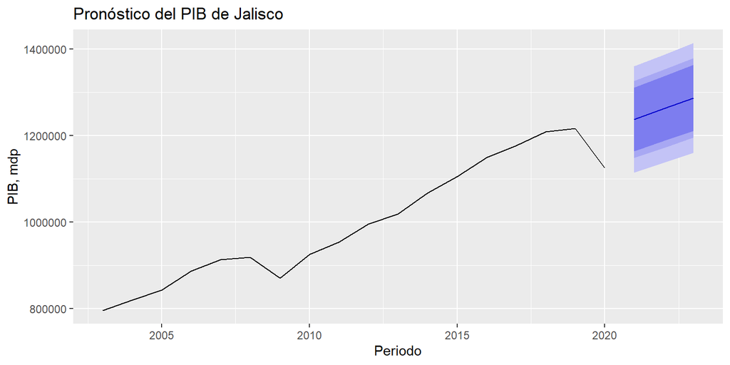

```r
autoplot(fcast) +
  ggtitle("Pronóstico del PIB de Jalisco") +
  xlab("Periodo") + ylab("PIB, mdp")
```

## 6.2 Datos trimestrales

```r
rm(list=ls())
data <- read_excel("BD_INDICADORES_MACROECONOMICOS.xlsx",
                   sheet = "Exportaciones")
```

```r
data <- data %>%
  group_by(Fecha) %>%
  summarise(exportaciones=sum(`Exportaciones totales`), .groups="drop") %>%
  mutate(periodo=dmy(Fecha)) %>%
  arrange(periodo)

export <- ts(data$exportaciones, start=c(2007, 1), end=c(2021, 3), frequency=4)
```

```r
regresion <- tslm(export ~ trend +season)
fcast <- forecast(regresion, h=12)

summary(regresion)
```

```
##
## Call:
## tslm(formula = export ~ trend + season)
##
## Residuals:
##       Min        1Q    Median        3Q       Max
## -36522062  -3692424   2643405   4657112  10569289
##
## Coefficients:
##             Estimate Std. Error t value Pr(>|t|)
## (Intercept) 50565597    2810553  17.991   <2e-16 ***
## trend         867040      63168  13.726   <2e-16 ***
## season2      4141606    3015119   1.374   0.1752
## season3      6176381    3017103   2.047   0.0455 *
## season4      7381706    3068465   2.406   0.0196 *
## ---
## Signif. codes:  0 '***' 0.001 '**' 0.01 '*' 0.05 '.' 0.1 ' ' 1
##
## Residual standard error: 8255000 on 54 degrees of freedom
## Multiple R-squared:  0.7856, Adjusted R-squared:  0.7697
## F-statistic: 49.47 on 4 and 54 DF,  p-value: < 2.2e-16
```

```r
fcast
```

```
##         Point Forecast     Lo 80     Hi 80     Lo 95     Hi 95
## 2021 Q4      109969716  98613618 121325814  92421434 127517998
## 2022 Q1      103455050  92086341 114823759  85887281 121022820
## 2022 Q2      108463696  97094987 119832405  90895927 126031466
## 2022 Q3      111365512  99996803 122734221  93797742 128933281
## 2022 Q4      113437877 102006322 124869432  95772993 131102760
## 2023 Q1      106923211  95474434 118371988  89231715 124614707
## 2023 Q2      111931857 100483080 123380634  94240361 129623353
## 2023 Q3      114833673 103384896 126282450  97142176 132525169
## 2023 Q4      116906038 105390185 128421890  99110891 134701184
## 2024 Q1      110391372  98853765 121928979  92562609 128220135
## 2024 Q2      115400018 103862411 126937625  97571255 133228781
## 2024 Q3      118301834 106764227 129839441 100473071 136130597
```

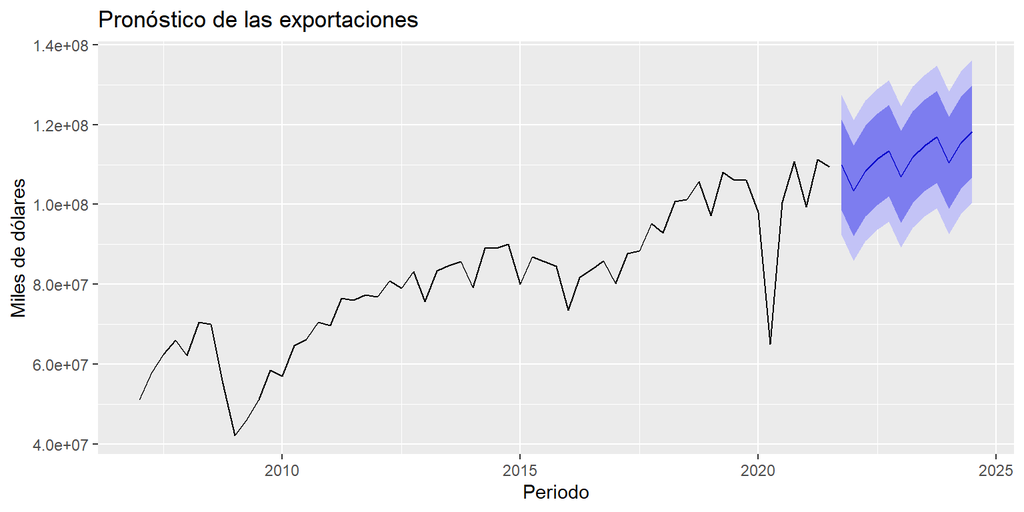

```r
autoplot(fcast) +
  ggtitle("Pronóstico de las exportaciones") +
  xlab("Periodo") + ylab("Miles de dólares")
```

## 6.3 Datos mensuales

```r
data <- read_excel("BD_INDICADORES_MACROECONOMICOS.xlsx",
                                             sheet = "IMSS")

data <- data %>%
  group_by(Fecha) %>%
  summarise(trabajadores=sum(`Trabajadores asegurados`), .groups="drop") %>%
  mutate(periodo=ymd(Fecha)) %>%
  arrange(periodo)

empleo <- ts(data$trabajadores, start=c(1998, 1), end=c(2021, 12), frequency=12)
```

```r
regresion <- tslm(empleo ~ trend + season)
fcast <- forecast(regresion, h=12)

summary(regresion)
```

```
##
## Call:
## tslm(formula = empleo ~ trend + season)
##
## Residuals:
##     Min      1Q  Median      3Q     Max
## -103159  -51102  -19997   57527  112359
##
## Coefficients:
##              Estimate Std. Error t value Pr(>|t|)
## (Intercept) 814811.72   14970.71  54.427   <2e-16 ***
## trend         3406.06      46.85  72.706   <2e-16 ***
## season2       4782.39   19064.11   0.251    0.802
## season3       7294.91   19064.28   0.383    0.702
## season4       4595.10   19064.57   0.241    0.810
## season5        637.12   19064.97   0.033    0.973
## season6      -1233.07   19065.49  -0.065    0.948
## season7      -1304.55   19066.12  -0.068    0.945
## season8       1276.97   19066.87   0.067    0.947
## season9       5823.70   19067.73   0.305    0.760
## season10     13638.59   19068.71   0.715    0.475
## season11     20340.36   19069.80   1.067    0.287
## season12      -490.54   19071.01  -0.026    0.979
## ---
## Signif. codes:  0 '***' 0.001 '**' 0.01 '*' 0.05 '.' 0.1 ' ' 1
##
## Residual standard error: 66040 on 275 degrees of freedom
## Multiple R-squared:  0.9507, Adjusted R-squared:  0.9485
## F-statistic: 441.8 on 12 and 275 DF,  p-value: < 2.2e-16
```

```r
fcast
```

```
##          Point Forecast   Lo 80   Hi 80   Lo 95   Hi 95
## Jan 2022        1799164 1712108 1886220 1665756 1932572
## Feb 2022        1807353 1720297 1894409 1673945 1940761
## Mar 2022        1813271 1726215 1900327 1679863 1946679
## Apr 2022        1813978 1726922 1901033 1680570 1947385
## May 2022        1813426 1726370 1900482 1680018 1946833
## Jun 2022        1814961 1727906 1902017 1681554 1948369
## Jul 2022        1818296 1731240 1905352 1684888 1951704
## Aug 2022        1824284 1737228 1911340 1690876 1957691
## Sep 2022        1832236 1745181 1919292 1698829 1965644
## Oct 2022        1843457 1756401 1930513 1710050 1976865
## Nov 2022        1853565 1766509 1940621 1720157 1986973
## Dec 2022        1836140 1749084 1923196 1702733 1969548
```

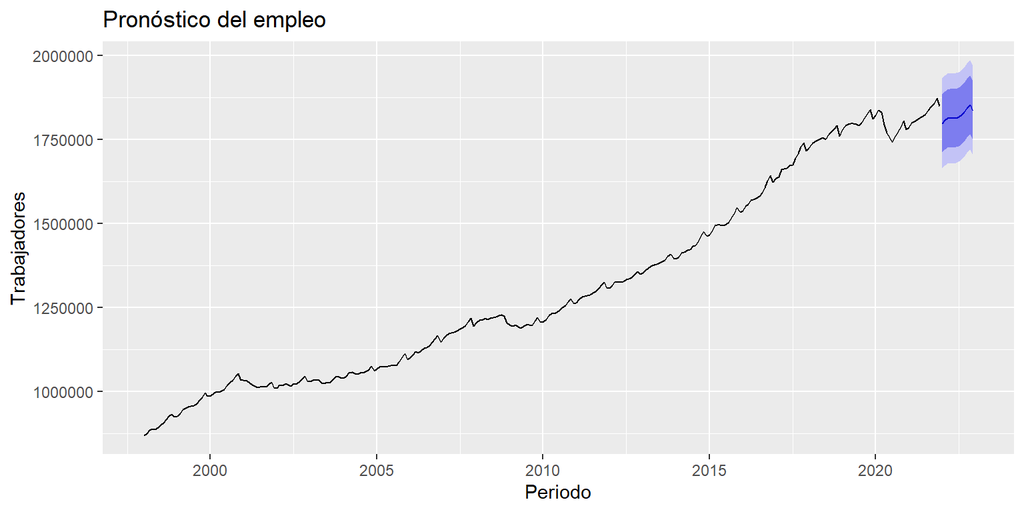

```r
autoplot(fcast) +
  ggtitle("Pronóstico del empleo") +
  xlab("Periodo") + ylab("Trabajadores")
```

## 6.4 Poner en práctica

Ahora te toca a ti, puedes replicar estos ejemplos ya sea usando la misma base de datos, pero con series para otras entidades o usando alguna serie de tiempo que sea de tu interés.